# athlete_events

SAMIRA

04/11/2021

1. We have been provided with data from the Olympic Games held over the past 120 years. This paper provides a brief analysis of these events. Since the data was split into several files, first you need to create a custom function to combine all files into one for the convenience of further work. The function works correctly and is presented below

```r
library(dplyr)
library(readr)
library(plyr)
library(devtools)
library(car)
```

```r
library(ggplot2)
```

```r
olympic_func <- function(path, format) {

   if (format == "csv") olympic_data1 <- {list.files(path, full.names = TRUE) %>% lapply(read_csv) %>% bind_rows} else{
       if (format == "txt") olympic_data1 <- {list.files(path, full.names = TRUE) %>% lapply(read_txt) %>% bind_rows}
       if (format == "xlsx") olympic_data1 <- {list.files(path, full.names = TRUE) %>% lapply(read_xlsx) %>% bind_rows}
     }

}
```

Now it is possible to load data.

```r
olympic_data <- olympic_func(path = "/home/samira/Samira/athlete_events/athlete_events/", format = "csv")
```

2. Let’s pay attention to the data structure. Different types of data are presented here. There are both line data and numerical data. Each line contains information about a specific participant in the game: his name, gender, age, height, weight, team, country, games, year, season, city, sport, event, award

```r
str(olympic_data)
```

```
## spec_tbl_df [271,115 × 15] (S3: spec_tbl_df/tbl_df/tbl/data.frame)
##  $ ID    : num [1:271115] 1 2 3 4 5 5 5 5 5 5 ...
##  $ Name  : chr [1:271115] "A Dijiang" "A Lamusi" "Gunnar Nielsen Aaby" "Edgar Lindenau Aabye" ...
##  $ Sex   : chr [1:271115] "M" "M" "M" "M" ...
##  $ Age   : num [1:271115] 24 23 24 34 21 21 25 25 27 27 ...
##  $ Height: num [1:271115] 180 170 NA NA 185 185 185 185 185 185 ...
##  $ Weight: num [1:271115] 80 60 NA NA 82 82 82 82 82 82 ...
##  $ Team  : chr [1:271115] "China" "China" "Denmark" "Denmark/Sweden" ...
##  $ NOC   : chr [1:271115] "CHN" "CHN" "DEN" "DEN" ...
##  $ Games : chr [1:271115] "1992 Summer" "2012 Summer" "1920 Summer" "1900 Summer" ...
##  $ Year  : num [1:271115] 1992 2012 1920 1900 1988 ...
##  $ Season: chr [1:271115] "Summer" "Summer" "Summer" "Summer" ...
##  $ City  : chr [1:271115] "Barcelona" "London" "Antwerpen" "Paris" ...
##  $ Sport : chr [1:271115] "Basketball" "Judo" "Football" "Tug-Of-War" ...
##  $ Event : chr [1:271115] "Basketball Men's Basketball" "Judo Men's Extra-Lightweight" "Football Men's Football" "Tug-Of-War Men's Tug-Of-War" ...
##  $ Medal : chr [1:271115] NA NA NA "Gold" ...
##  - attr(*, "spec")=
##   .. cols(
##   ..   ID = col_double(),
##   ..   Name = col_character(),
##   ..   Sex = col_character(),
##   ..   Age = col_double(),
##   ..   Height = col_double(),
##   ..   Weight = col_double(),
##   ..   Team = col_character(),
##   ..   NOC = col_character(),
##   ..   Games = col_character(),
##   ..   Year = col_double(),
##   ..   Season = col_character(),
##   ..   City = col_character(),
##   ..   Sport = col_character(),
##   ..   Event = col_character(),
##   ..   Medal = col_character()
##   .. )
##  - attr(*, "problems")=<externalptr>
```

Everything seems to be correct except for the country information. In some places it is written Russia-1, Russia-2, etc. You can try to delete non-letter characters.

```r
olympic_data$Team <- gsub('[0-9,-]+', '', olympic_data$Team)
```

```r
#it is better to make weight integer value
olympic_data$Weight <- as.integer(olympic_data$Weight)
```

Let’s do a little computational analysis to get a closer look at the data.

3. Let’s find out the age of the youngest athletes of both sexes at the 1992 Olympics.

```r
youngest_man_92 <- olympic_data %>% filter(Year == 1992 & Sex == "M") %>% pull(Age)
min(youngest_man_92, na.rm = TRUE)
```

```
## [1] 11
```

```r
youngest_woman_92 <- olympic_data %>% filter(Year == 1992 & Sex == "F") %>% pull(Age)
min(youngest_woman_92, na.rm = TRUE)
```

```
## [1] 12
```

```r
mean(olympic_data$Height, na.rm = TRUE)
```

```
## [1] 175.3398
```

```r
sd(olympic_data$Height, na.rm = TRUE)
```

```
## [1] 10.52462
```

```r
height_tennis_woman <- olympic_data %>% filter(Year == 2000 & Sex == "F") %>% pull(Height)
round(mean(height_tennis_woman, na.rm = TRUE), 1)
```

```
## [1] 169
```

```r
round(sd(height_tennis_woman, na.rm = TRUE), 1)
```

```
## [1] 9.5
```

6. To find out which sport the heaviest athlete participated in in the 2006 Olympics, first find out the weight of the heaviest athlete in the 2006 Olympics.

```r
heaviest_athlet <- subset(olympic_data, Year == 2006, select = Weight)
max(heaviest_athlet, na.rm = TRUE)
```

```
## [1] 127
```

He turned out to be 127 kg, now we can find out what kind of sport he participated in.

```r
weight_athlet <- olympic_data %>% filter(Year == 2006 &  Weight == 127) %>% pull(Sport)
weight_athlet
```

```
## [1] "Skeleton"
```

7. It is interesting to look at the number of gold medals received by women from 1980 to 2010

```r
medals <- subset(olympic_data, Year == c(1980:2010) & Sex == "F" , select = Medal)
woman_gold <- medals %>% filter(Medal == "Gold")
length(rownames(woman_gold))
```

```
## [1] 80
```

80 medals were received y women from 1980 to 2010.

8. It is also possible to find out how many times a particular athlete participated in the Olympic Games in different years.

```r
sportsmen <- olympic_data %>% filter(Name == "John Aalberg")
unique(sportsmen$Year)
```

```
## [1] 1992 1994
```

So the athlete John Aalberg participated in different years: in 1992 and 1994.

9. The least and most represented (by number of participants) age groups of athletes at the 2008 Olympic Games can be identified.

```r
members <- subset(olympic_data, Year == 2008, select = Age)

members1 <- members %>% filter(Age == c(15:24))
length(rownames(members1))
```

```
## [1] 617
```

```r
members2 <- members %>% filter(Age == c(25:34))
length(rownames(members2))
```

```
## [1] 620
```

```r
members3 <- members %>% filter(Age == c(35:44))
length(rownames(members3))
```

```
## [1] 86
```

```r
members4 <- members %>% filter(Age == c(45:55))
length(rownames(members4))
```

```
## [1] 16
```

So in age groups: [15-25) - 617 participants [25-35) - 620 participants [35-45) - 86 participants [45-55] - 16 participant. As we can see, the least number of participants in the group with age [45-55]

10. It is interesting how the number of sports changed at the Olympics from 1994 to 2002

```r
type_sports_2002 <- olympic_data %>% filter(Year == 2002 ) %>% pull(Sport)
type_sports_1994 <- olympic_data %>% filter(Year == 1994 ) %>% pull(Sport)
length(unique(type_sports_2002)) - length(unique(type_sports_1994))
```

```
## [1] 3
```

So, in 2002, 3 new sports appeared.

11. Output for the winter and summer Olympiads separately the top 3 countries for each type of medal.

```r
winter_gold <- olympic_data %>% filter( Season == "Winter", Medal == "Gold" ) %>% pull(Team)

winter_silver <- olympic_data %>% filter( Season == "Winter", Medal == "Silver" ) %>% pull(Team)

winter_bronze <- olympic_data %>% filter( Season == "Winter", Medal == "Bronze" ) %>% pull(Team)

summer_gold <- olympic_data %>% filter( Season == "Summer", Medal == "Gold" ) %>% pull(Team)

summer_silver <- olympic_data %>% filter( Season == "Summer", Medal == "Silver" ) %>% pull(Team)

summer_bronze <- olympic_data %>% filter( Season == "Summer", Medal == "Bronze" ) %>% pull(Team)
```

TOP-3 Teams with Gold medals in winter season:

```r
tail(sort(table(winter_gold)),  3) # US, SU,Canada - gold actually we can summarize medals from SU and Russia and that will put the SU on the 1st place
```

```
## winter_gold
## United States  Soviet Union        Canada
##           166           250           305
```

But, actually, if we take a look on top-10 we can find Russia that is why we can summarize medals from SU and Russia and that will put the SU on the 1st place :)

```r
tail(sort(table(winter_gold)),  10)
```

```
## winter_gold
##       Finland   Switzerland       Austria        Russia        Sweden
##            66            76            79            94           125
##        Norway       Germany United States  Soviet Union        Canada
##           151           153           166           250           305
```

TOP-3 Teams with Silver medals in winter season:

```r
tail(sort(table(winter_silver)),  3)
```

```
## winter_silver
##        Norway        Canada United States
##           165           199           308
```

TOP-3 Teams with Bronze medals in winter season:

```r
tail(sort(table(winter_bronze)),  3)
```

```
## winter_bronze
## United States        Sweden       Finland
##           161           177           215
```

TOP-3 Teams with Gold medals in summer season:

```r
tail(sort(table(summer_gold)),  3)
```

```
## summer_gold
##       Germany  Soviet Union United States
##           568           830          2363
```

TOP-3 Teams with Silver medals in summer season:

```r
tail(sort(table(summer_silver)),  3)
```

```
## summer_silver
## Great Britain  Soviet Union United States
##           594           635          1251
```

TOP-3 Teams with Bronze medals in summer season:

```r
tail(sort(table(summer_bronze)),  3)
```

```
## summer_bronze
##  Soviet Union       Germany United States
##           596           614          1126
```

12. Standardizing a variable Height_z_scores and store the values of the Height variable in it after standardizing it.

```r
olympic_data <- olympic_data %>% mutate(Height_z_scores = (scale(Height)))
```

But it was possible to create a variable and not add a column. Then it would be possible to count without NA values.

```r
Height_new <- na.omit(olympic_data$Height)
Height_z_scores_new <- scale(Height_new)
mean(Height_z_scores_new)
```

```
## [1] -4.994655e-17
```

```r
sd(Height_z_scores_new)
```

```
## [1] 1
```

14. Let’s compare how different the physical indicators such as weight, age, and height of men and women who participated in the Winter Olympics are.

```r
olymp_data_winter <- subset(olympic_data, Season == "Winter")
```

```r
olymp_data_winter <- olymp_data_winter %>% mutate(Sex = replace(Sex, Sex == "M", "1")) %>%
   mutate(Sex = replace(Sex, Sex == "F", "2"))
olymp_data_winter$Sex <- as.factor(olymp_data_winter$Sex)
str(olymp_data_winter)
```

```
## tibble [48,564 × 16] (S3: tbl_df/tbl/data.frame)
##  $ ID             : num [1:48564] 5 5 5 5 5 5 6 6 6 6 ...
##  $ Name           : chr [1:48564] "Christine Jacoba Aaftink" "Christine Jacoba Aaftink" "Christine Jacoba Aaftink" "Christine Jacoba Aaftink" ...
##  $ Sex            : Factor w/ 2 levels "1","2": 2 2 2 2 2 2 1 1 1 1 ...
##  $ Age            : num [1:48564] 21 21 25 25 27 27 31 31 31 31 ...
##  $ Height         : num [1:48564] 185 185 185 185 185 185 188 188 188 188 ...
##  $ Weight         : int [1:48564] 82 82 82 82 82 82 75 75 75 75 ...
##  $ Team           : chr [1:48564] "Netherlands" "Netherlands" "Netherlands" "Netherlands" ...
##  $ NOC            : chr [1:48564] "NED" "NED" "NED" "NED" ...
##  $ Games          : chr [1:48564] "1988 Winter" "1988 Winter" "1992 Winter" "1992 Winter" ...
##  $ Year           : num [1:48564] 1988 1988 1992 1992 1994 ...
##  $ Season         : chr [1:48564] "Winter" "Winter" "Winter" "Winter" ...
##  $ City           : chr [1:48564] "Calgary" "Calgary" "Albertville" "Albertville" ...
##  $ Sport          : chr [1:48564] "Speed Skating" "Speed Skating" "Speed Skating" "Speed Skating" ...
##  $ Event          : chr [1:48564] "Speed Skating Women's 500 metres" "Speed Skating Women's 1,000 metres" "Speed Skating Women's 500 metres" "Speed Skating Women's 1,000 metres" ...
##  $ Medal          : chr [1:48564] NA NA NA NA ...
##  $ Height_z_scores: num [1:48564, 1] 0.918 0.918 0.918 0.918 0.918 ...
##   ..- attr(*, "scaled:center")= num 175
##   ..- attr(*, "scaled:scale")= num 10.5
```

```r
df1 <- filter(olymp_data_winter, Sex %in% c(1,2))
```

```r
Height_fem <- olymp_data_winter %>% filter(Sex == 2) %>% pull(Height)
Height_male <- olymp_data_winter %>% filter(Sex == 1) %>% pull(Height)
```

Normality check

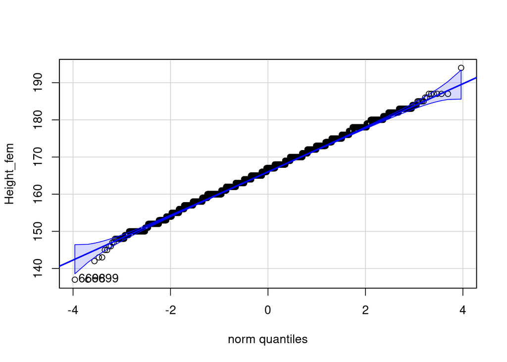

```
## [1] 6698 6699
```

```r
qqPlot(Height_fem)
```

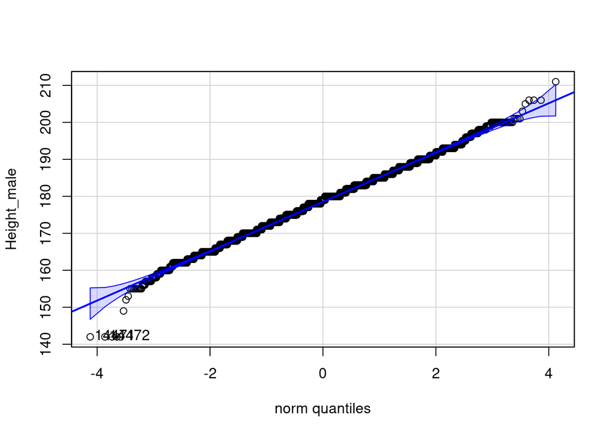

```
## [1] 14471 14472
```

```r
qqPlot(Height_male)
```

We assume that the data is distributed normally.

We checked the equality of variances using the Fisher test:

```r
var.test(Height_fem, Height_male)
```

```
##
##  F test to compare two variances
##
## data:  Height_fem and Height_male
## F = 0.8394, num df = 13522, denom df = 26726, p-value < 2.2e-16
## alternative hypothesis: true ratio of variances is not equal to 1
## 95 percent confidence interval:
##  0.8152594 0.8643790
## sample estimates:
## ratio of variances
##          0.8394003
```

The two-sample Welch t-test was used to test the significance of the differences between the means. differences in variances in 2 groups are statistically significant:

```r
t.test(Height_fem, Height_male, var.equal = FALSE)
```

```
##
##  Welch Two Sample t-test
##
## data:  Height_fem and Height_male
## t = -184.8, df = 29342, p-value < 2.2e-16
## alternative hypothesis: true difference in means is not equal to 0
## 95 percent confidence interval:
##  -12.26962 -12.01208
## sample estimates:
## mean of x mean of y
##  166.5283  178.6691
```

t = -184.8, df = 29342, p-value < 2.2e-16

The resulting differences are statistically significant, and we can accept an alternative hypothesis, which says that in these two groups (the height of men and women), the average height is different.

Let’s see what result we would get if we used t-test without Welch’s correction:

```r
t.test(Height_fem, Height_male, var.equal = TRUE)
```

```
##
##  Two Sample t-test
##
## data:  Height_fem and Height_male
## t = -179.58, df = 40248, p-value < 2.2e-16
## alternative hypothesis: true difference in means is not equal to 0
## 95 percent confidence interval:
##  -12.27336 -12.00834
## sample estimates:
## mean of x mean of y
##  166.5283  178.6691
```

t = -179.58, df = 40248, p-value < 2.2e-16

In this case, the result does not change, and the difference is still statistically significant.

To visualize the distributions, a Boxplot was built for the compared groups:

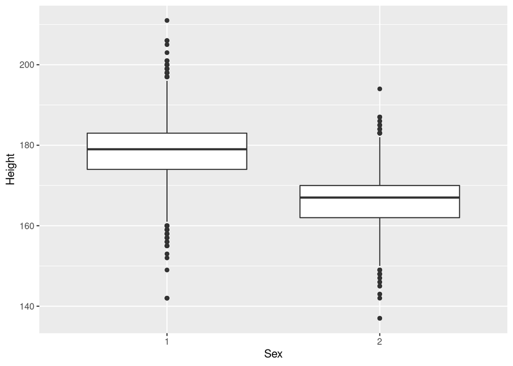

```r
ggplot(df1, aes((Sex), Height))+
  geom_boxplot()+
  xlab("Sex")+
  ylab("Height")
```

And also a graph with confidence intervals and averages for both groups:

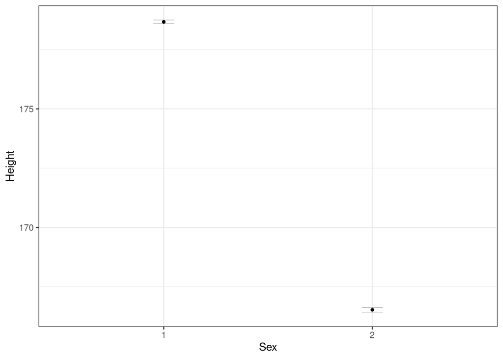

```r
ggplot(df1, aes(as.factor(Sex), Height))+
  stat_summary(fun.data = mean_cl_boot, geom = "errorbar", width=0.1, size=0.1)+
  stat_summary(fun = mean, geom = "point", size=1)+
  theme_bw()+
  xlab("Sex")+
  ylab("Height")
```

Based on the resulting graph, it can also be concluded that the differences are statistically significant (the mean of 1 sample is not included in the confidence interval for the 2 mean and vice versa).

A similar analysis can be done with other physical parameters: age and weight

```r
Weight_fem <- olymp_data_winter %>% filter(Sex == 2) %>% pull(Weight)
Weight_male <- olymp_data_winter %>% filter(Sex == 1) %>% pull(Weight)
```

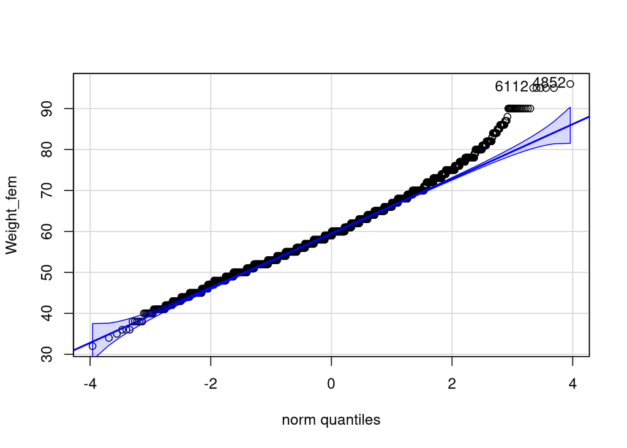

```
## [1] 4852 6112
```

```r
qqPlot(Weight_fem)
```

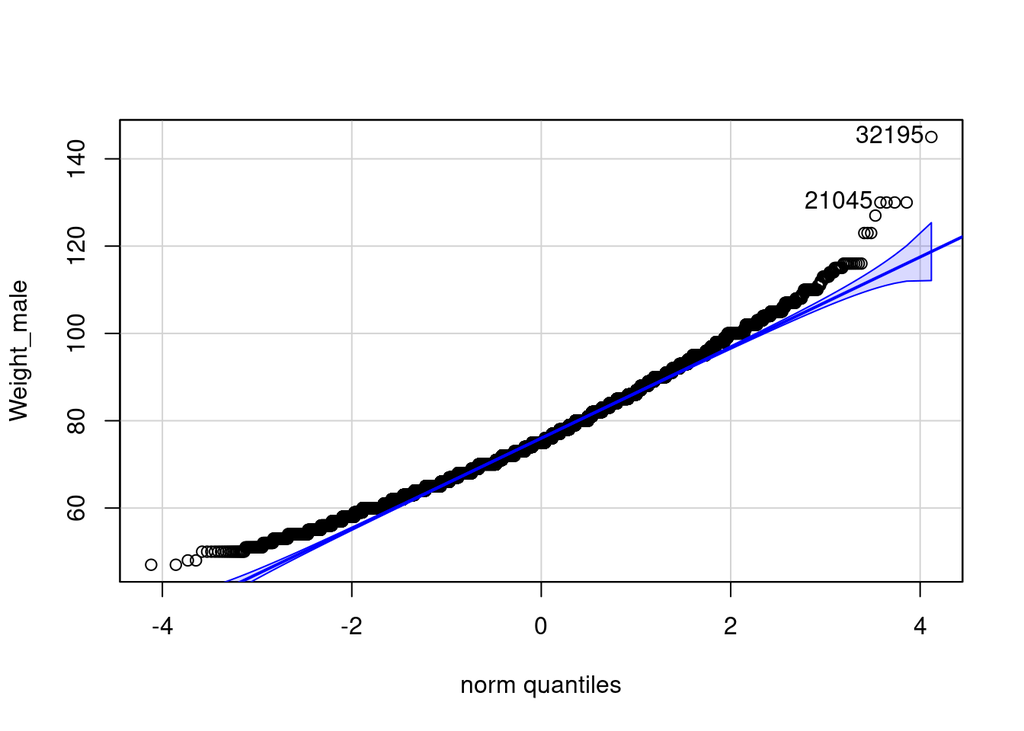

```
## [1] 32195 21045
```

```r
qqPlot(Weight_male)
```

```r
var.test(Weight_fem, Weight_male)
```

```
##
##  F test to compare two variances
##
## data:  Weight_fem and Weight_male
## F = 0.46688, num df = 13333, denom df = 26208, p-value < 2.2e-16
## alternative hypothesis: true ratio of variances is not equal to 1
## 95 percent confidence interval:
##  0.453345 0.480884
## sample estimates:
## ratio of variances
##           0.466878
```

F = 0.46688, num df = 13333, denom df = 26208, p-value < 2.2e-16

```r
t.test(Weight_fem, Weight_male, var.equal = FALSE)
```

```
##
##  Welch Two Sample t-test
##
## data:  Weight_fem and Weight_male
## t = -187.84, df = 36296, p-value < 2.2e-16
## alternative hypothesis: true difference in means is not equal to 0
## 95 percent confidence interval:
##  -16.77514 -16.42867
## sample estimates:
## mean of x mean of y
##  59.75259  76.35450
```

t = -187.85, df = 36296, p-value < 2.2e-16

```r
t.test(Weight_fem, Weight_male, var.equal = TRUE)
```

```
##
##  Two Sample t-test
##
## data:  Weight_fem and Weight_male
## t = -166.78, df = 39541, p-value < 2.2e-16
## alternative hypothesis: true difference in means is not equal to 0
## 95 percent confidence interval:
##  -16.79701 -16.40680
## sample estimates:
## mean of x mean of y
##  59.75259  76.35450
```

t = -166.79, df = 39541, p-value < 2.2e-16

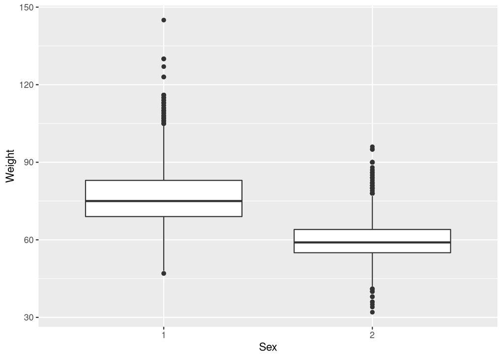

```r
ggplot(df1, aes((Sex), Weight))+
  geom_boxplot()+
  xlab("Sex")+
  ylab("Weight")
```

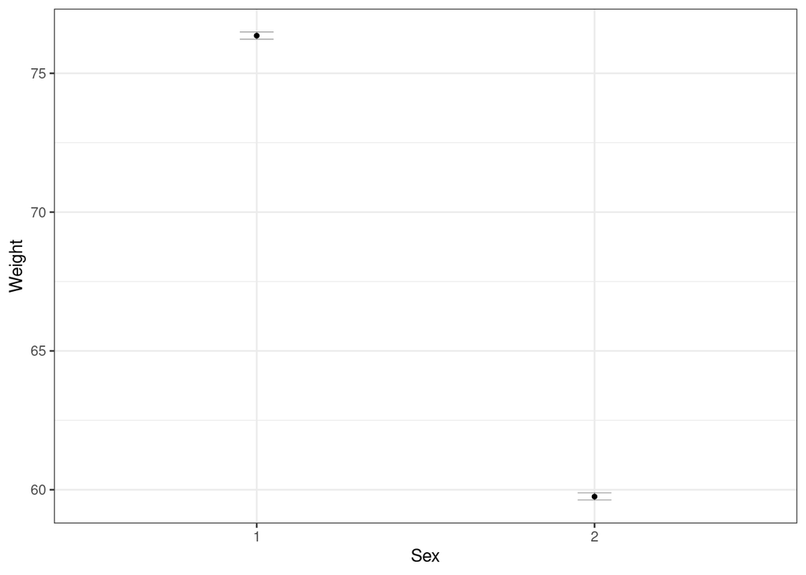

```r
ggplot(df1, aes(as.factor(Sex), Weight))+
  stat_summary(fun.data = mean_cl_boot, geom = "errorbar", width=0.1, size=0.1)+
  stat_summary(fun = mean, geom = "point", size=1)+
  theme_bw()+
  xlab("Sex")+
  ylab("Weight")
```

Comparison of ages:

```r
Age_fem <- olymp_data_winter %>% filter(Sex == 2) %>% pull(Age)
Age_male <- olymp_data_winter %>% filter(Sex == 1) %>% pull(Age)
```

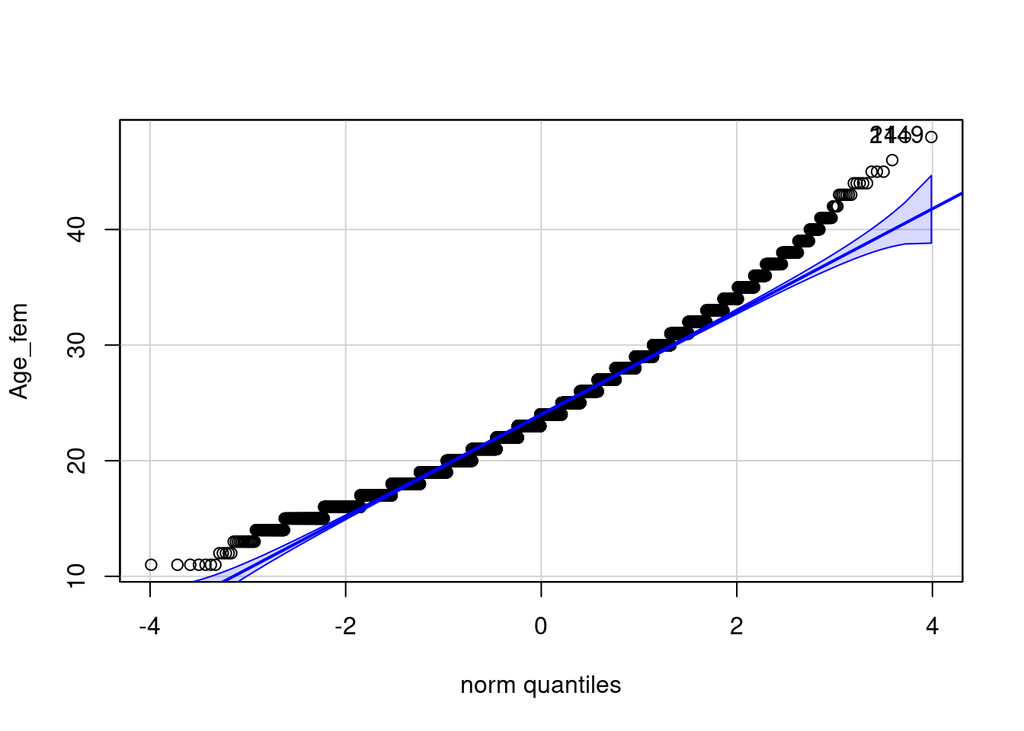

```
## [1]   14 2149
```

```r
qqPlot(Age_fem)
```

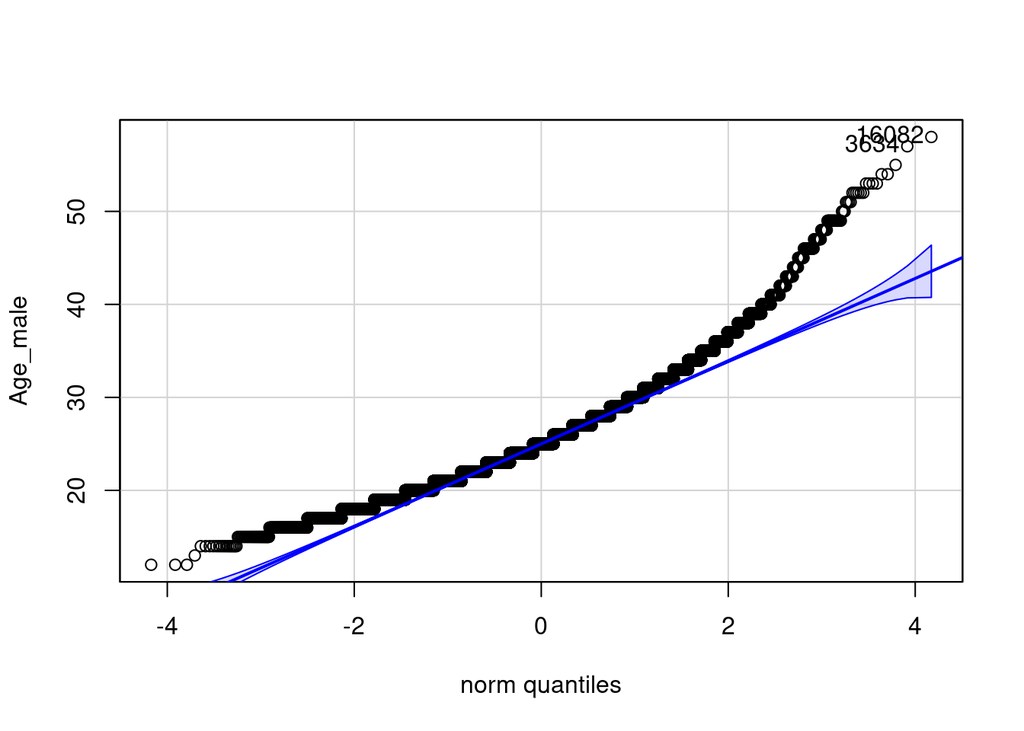

```
## [1] 16082  3634
```

```r
qqPlot(Age_male)
```

```r
var.test(Age_fem, Age_male)
```

```
##
##  F test to compare two variances
##
## data:  Age_fem and Age_male
## F = 0.97635, num df = 15072, denom df = 33205, p-value = 0.08559
## alternative hypothesis: true ratio of variances is not equal to 1
## 95 percent confidence interval:
##  0.9501903 1.0033615
## sample estimates:
## ratio of variances
##          0.9763452
```

F = 0.97635, num df = 15072, denom df = 33205, p-value = 0.08559

The differences in variances in 2 groups are statistically insignificant:

t-test without Welch’s correction:

```r
t.test(Age_fem, Age_male, var.equal = TRUE)
```

```
##
##  Two Sample t-test
##
## data:  Age_fem and Age_male
## t = -32.095, df = 48277, p-value < 2.2e-16
## alternative hypothesis: true difference in means is not equal to 0
## 95 percent confidence interval:
##  -1.581206 -1.399193
## sample estimates:
## mean of x mean of y
##   24.0142   25.5044
```

t = -32.095, df = 48277, p-value < 2.2e-16

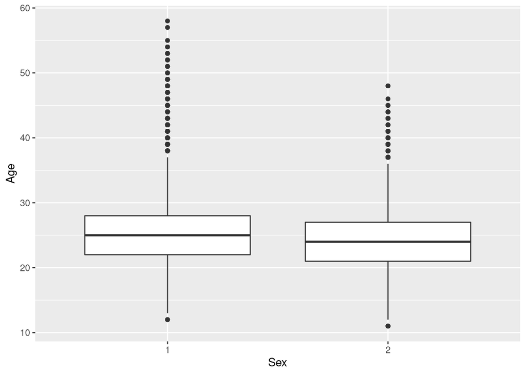

```r
ggplot(df1, aes(as.factor(Sex), Age))+
  geom_boxplot()+
  xlab("Sex")+
  ylab("Age")
```

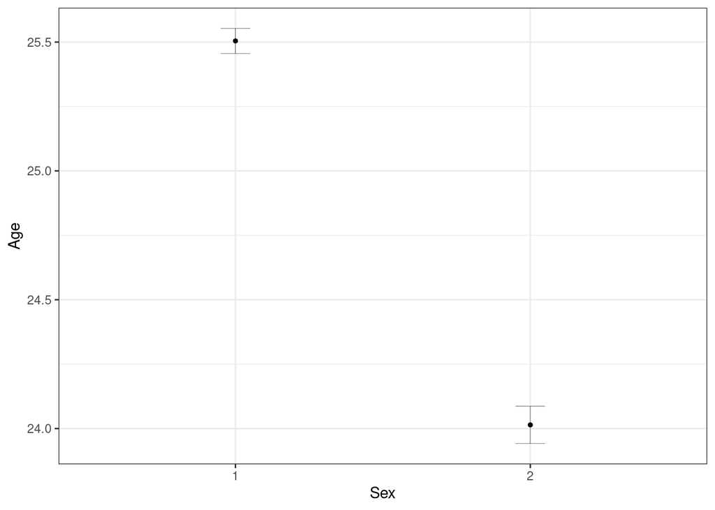

```r
ggplot(df1, aes(as.factor(Sex), Age))+
  stat_summary(fun.data = mean_cl_boot, geom = "errorbar", width=0.1, size=0.1)+
  stat_summary(fun = mean, geom = "point", size=1)+
  theme_bw()+
  xlab("Sex")+
  ylab("Age")
```